# Modeling and prediction for movies by Islam

## Setup

### Load packages

```r
library(ggplot2)
library(grid)
library(gridExtra)
library(dplyr)
library(statsr)
library(GGally)
```

### Load data

```r
load("movies.Rdata")
```

## Part 1: Data

The Movies dataset consists of 651 randomly selected movies produced and published up to 2016. This dataset contains information from both Rotten Tomatoes and IMDb.

This dataset includes genre, genre, running time, studio, release, critics, director, etc. Target audience for this dataset is American films released in theaters from 1970 to 2014. The movies that make up this dataset are randomly selected from two well-known Internet movie databases: Rotten Tomatoes and IMDb.

### Scope of Inference

From the points outlined above, it seems clear that the films dataset should be viewed as an observational retrospective study using a random sampling design to select a representative sample of US films.

### Generalizability

The results from the data should be generalized for all US films released between 1970 and 2014.

### Causality

As we know, it is not recommended to draw causal conclusions based on observational data. Observational studies are enough just to show the relationship.

## Part 2: Research question

What makes a movie popular? To a tricky question to answer, the simple answer is total movie profit (theaters and DVD sales). However, since our dataset does not include the revenues and costs from the various films it contains, we need to choose another variable that can characterize the popularity of the film.

Our choice variable will be the IMDb rating (imdb_rating) and / or critics score (viewer_ rating). It is well known that good reviews on IMDb or Metacritic are contingent upon high movie earnings.

Our analysis will focus on answering the following research question: “Can we anticipate the popularity of a movie critics score only knowing its type (title_type variable), genre (genre variable), runtime (runtime variable), MPAA rating (Variable Mpaa_rating). , release month (thtr_rel_month variable), release date (thtr_rel_day variable), IMDb votes (imdb_num_votes variable), critics rating (crisics_score variable) and best picture nomination (best_pic_nom variable)?”.

## Part 3: Exploratory data analysis

### Response variable distribution

To begin with, we need to check if there is a high correlation between these two varibles: imdb_rating and critics_score

```r
cor(movies$imdb_rating, movies$critics_score)
```

```
## [1] 0.7650355
```

Observing the high correlation between both variables, we may only proceed with one of them. We will select critics_score ast the response variable.

Firstly, we need to drop all excessive variables by subsetting for ones we have interest and obliterating all NA values.

```r
movies_simp <- movies %>%
  select(critics_score, title_type, genre, runtime, critics_rating, thtr_rel_month, thtr_rel_day, imdb_num_votes, audience_score, best_pic_nom) %>%
  filter(runtime != "NA")
```

Let’s see what we have in the response variable by plotting a histogram

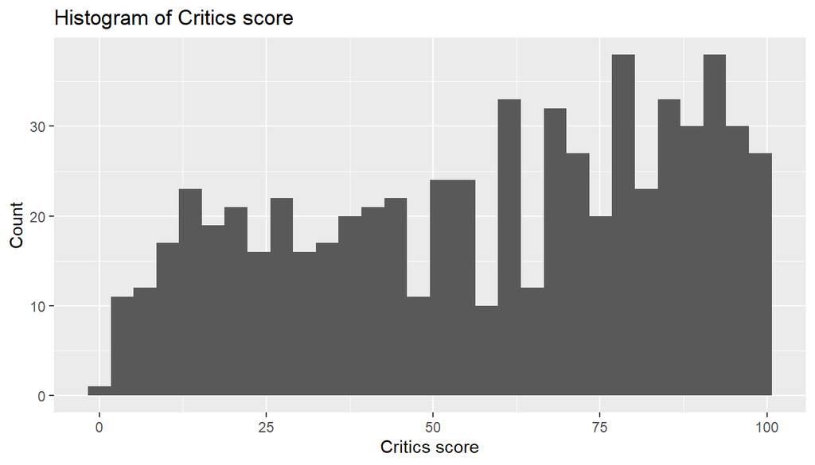

```r
ggplot(movies_simp, aes(x = critics_score)) +
  geom_histogram() + xlab("Critics score") + ylab("Count") + ggtitle("Histogram of Critics score")
```

```r
summary(movies_simp["critics_score"])
```

```
##  critics_score
##  Min.   :  1.00
##  1st Qu.: 33.00
##  Median : 61.00
##  Mean   : 57.65
##  3rd Qu.: 83.00
##  Max.   :100.00
```

The distribution displays a moderate left-skewness.

### Boxplots of Response & Categorical variables

Having all the experince and backround we can start our exploratory data analysis. We will begin by using boxplots to show in which way our categorical variables of interest impact on the response variable.

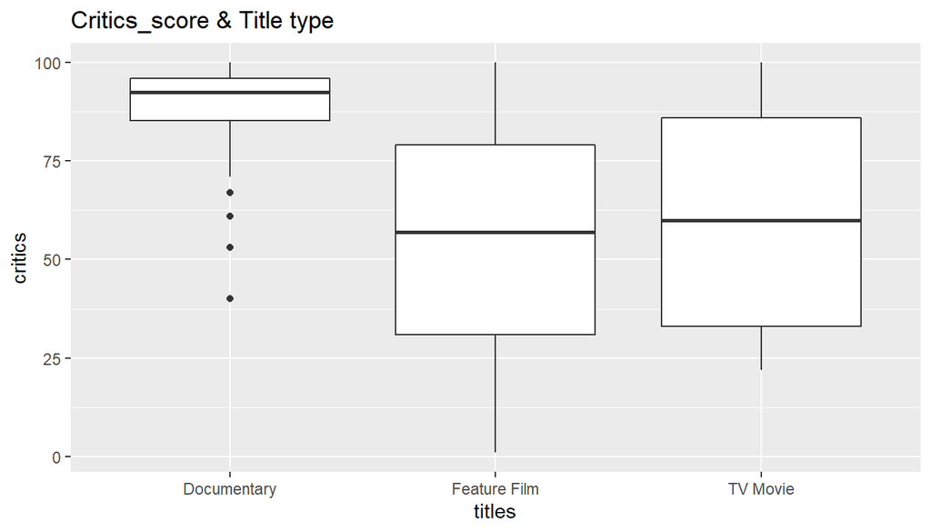

```r
ggplot(movies_simp, aes(x = title_type, y = critics_score)) +
         geom_boxplot() + xlab("titles") + ylab("critics") + ggtitle("Critics_score & Title type")
```

```r
movies_simp %>%
  group_by(title_type) %>%
  summarise(median_score = median(critics_score), IQR(critics_score))
```

```
## # A tibble: 3 x 3
##   title_type   median_score `IQR(critics_score)`
##   <fct>               <dbl>                <dbl>
## 1 Documentary          92.5                 10.8
## 2 Feature Film         57                   48
## 3 TV Movie             60                   53
```

It seems that the resonse varible and varible Title Type are associated with one another, alhough there are several outliers in the Documentary category.

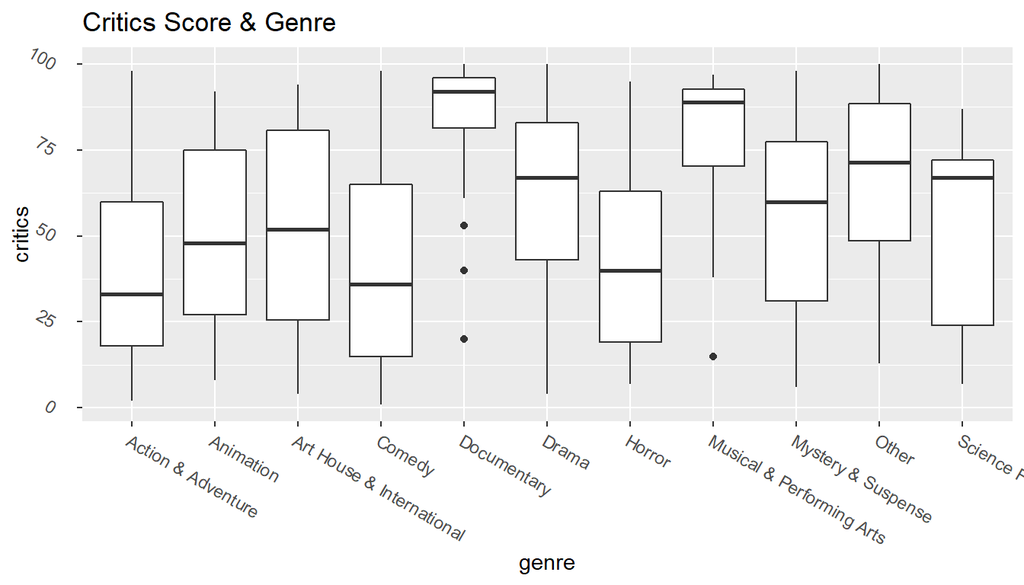

```r
ggplot(movies_simp, aes(x = genre, y = critics_score)) +
  geom_boxplot() + xlab("genre") + ylab("critics") + ggtitle("Critics Score & Genre") + theme(axis.text = element_text(angle = -30, hjust = 0))
```

```r
movies_simp %>% group_by(genre) %>% summarise(median_score = median(critics_score), iqr_score = IQR(critics_score))
```

```
## # A tibble: 11 x 3
##    genre                     median_score iqr_score
##    <fct>                            <dbl>     <dbl>
##  1 Action & Adventure                33        42
##  2 Animation                         48        48
##  3 Art House & International         52        55.2
##  4 Comedy                            36        50
##  5 Documentary                       92        14.5
##  6 Drama                             67        40
##  7 Horror                            40        44
##  8 Musical & Performing Arts         89        22.5
##  9 Mystery & Suspense                60        46.5
## 10 Other                             71.5      40
## 11 Science Fiction & Fantasy         67        48
```

This plot, likewise, shows that variables genre and the response critics_score are associated.

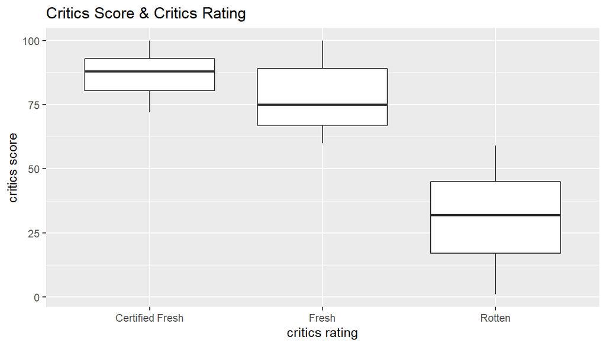

```r
ggplot(movies_simp, aes(x = critics_rating, y = critics_score)) +
  geom_boxplot() + xlab("critics rating") + ylab("critics score") +
  ggtitle("Critics Score & Critics Rating")
```

```r
movies_simp %>%
  group_by(critics_rating) %>%
  summarise(median_score = median(critics_score), iqr_score = IQR(critics_score))
```

```
## # A tibble: 3 x 3
##   critics_rating  median_score iqr_score
##   <fct>                  <dbl>     <dbl>
## 1 Certified Fresh           88      12.5
## 2 Fresh                     75      22
## 3 Rotten                    32      28
```

Here, it shows similar pattern of association

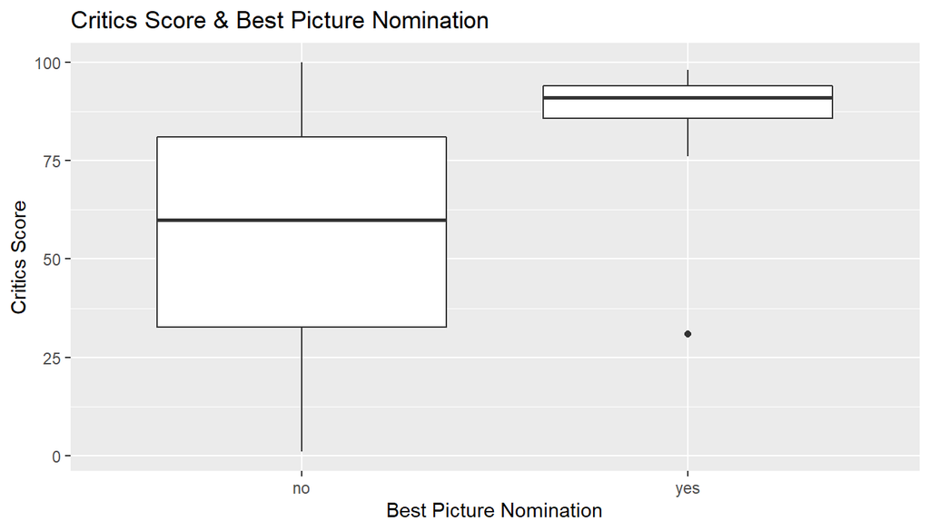

```r
ggplot(movies_simp, aes(x = best_pic_nom, y = critics_score)) +
  geom_boxplot() + xlab("Best Picture Nomination") + ylab("Critics Score") +
  ggtitle("Critics Score & Best Picture Nomination")
```

```r
movies_simp %>% group_by(best_pic_nom) %>%
  summarise(median_score = median(critics_score), iqr_score = IQR(critics_score))
```

```
## # A tibble: 2 x 3
##   best_pic_nom median_score iqr_score
##   <fct>               <dbl>     <dbl>
## 1 no                     60     48.2
## 2 yes                    91      8.25
```

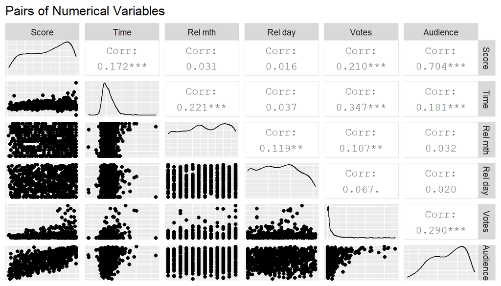

```r
ggpairs(movies_simp, columns = c(1, 4, 6, 7, 8, 9), axisLabels = "none", columnLabels = c("Score", "Time", "Rel mth", "Rel day", "Votes", "Audience"), title = "Pairs of Numerical Variables")
```

We’ve shown than the correlations among preditors are not out of the wedge, which is good, as modelling requires low level of correlation to eshew collinearity. Also, we can observe that the variables thtr_rel_month and thtr_rel_day do not seem to be good predictors for our response variable. Furthermore, the distributiom of the imdb_num_votes variable seem to be categorized by right-skewness, therefore we will transmute this variable by using the natural log.

```r
movies_simp <- movies_simp %>%
  mutate(log_imdb_num_votes = log(imdb_num_votes)) %>%
  select(-thtr_rel_month, -thtr_rel_month, -imdb_num_votes)
```

## Part 4: Modeling

### Starting Model

Now we have all the elements to create our first linear model to anticipate our repsonse variable. At the starting point, we’ll include all our variables of study: title_type, genre, runtime, log_imdb_num_votes, audience_score and best_pic_nom.

```r
mov1 <- lm(critics_score ~ title_type + genre + runtime + log_imdb_num_votes + audience_score + best_pic_nom, data = movies_simp)
summary(mov1)
```

```
##
## Call:
## lm(formula = critics_score ~ title_type + genre + runtime + log_imdb_num_votes +
##     audience_score + best_pic_nom, data = movies_simp)
##
## Residuals:
##     Min      1Q  Median      3Q     Max
## -61.036 -13.629   2.076  14.250  50.692
##
## Coefficients:
##                                  Estimate Std. Error t value Pr(>|t|)
## (Intercept)                     13.069292   9.578119   1.364 0.172897
## title_typeFeature Film         -23.209791   7.298538  -3.180 0.001544 **
## title_typeTV Movie             -17.009410  11.434083  -1.488 0.137353
## genreAnimation                   2.039813   7.000550   0.291 0.770857
## genreArt House & International   1.387529   5.903355   0.235 0.814253
## genreComedy                      0.296304   3.239192   0.091 0.927144
## genreDocumentary                -1.864634   7.765732  -0.240 0.810322
## genreDrama                       9.890660   2.815012   3.514 0.000474 ***
## genreHorror                      9.988468   4.785531   2.087 0.037267 *
## genreMusical & Performing Arts   4.068826   6.742384   0.603 0.546412
## genreMystery & Suspense         11.058739   3.533679   3.130 0.001831 **
## genreOther                      10.531550   5.570155   1.891 0.059119 .
## genreScience Fiction & Fantasy  11.215138   6.952245   1.613 0.107206
## runtime                          0.047157   0.044661   1.056 0.291417
## log_imdb_num_votes              -0.009752   0.583018  -0.017 0.986660
## audience_score                   0.869747   0.047019  18.498  < 2e-16 ***
## best_pic_nomyes                  7.587601   4.537325   1.672 0.094967 .
## ---
## Signif. codes:  0 '***' 0.001 '**' 0.01 '*' 0.05 '.' 0.1 ' ' 1
##
## Residual standard error: 19.53 on 633 degrees of freedom
## Multiple R-squared:  0.539,  Adjusted R-squared:  0.5273
## F-statistic: 46.25 on 16 and 633 DF,  p-value: < 2.2e-16
```

### Model Selection

Now we will select the best model answering our research question by performing a backward adjusted R-squared elimination. It denotes we will eliminate our variables one by one and see how it reflects to R-squared. We’ll start with log_imdb_num_votes.

```r
mov2 <- lm(critics_score ~ title_type + genre + runtime  + audience_score + best_pic_nom, data = movies_simp)
summary(mov2)
```

```
##
## Call:
## lm(formula = critics_score ~ title_type + genre + runtime + audience_score +
##     best_pic_nom, data = movies_simp)
##
## Residuals:
##     Min      1Q  Median      3Q     Max
## -61.031 -13.630   2.065  14.264  50.703
##
## Coefficients:
##                                 Estimate Std. Error t value Pr(>|t|)
## (Intercept)                     13.01978    9.10202   1.430 0.153087
## title_typeFeature Film         -23.23139    7.17772  -3.237 0.001273 **
## title_typeTV Movie             -17.02038   11.40626  -1.492 0.136145
## genreAnimation                   2.04125    6.99450   0.292 0.770507
## genreArt House & International   1.40810    5.76928   0.244 0.807257
## genreComedy                      0.30184    3.21969   0.094 0.925338
## genreDocumentary                -1.84898    7.70307  -0.240 0.810383
## genreDrama                       9.90235    2.72476   3.634 0.000301 ***
## genreHorror                      9.99387    4.77086   2.095 0.036587 *
## genreMusical & Performing Arts   4.08627    6.65594   0.614 0.539482
## genreMystery & Suspense         11.06317    3.52096   3.142 0.001756 **
## genreOther                      10.54292    5.52417   1.909 0.056777 .
## genreScience Fiction & Fantasy  11.21856    6.94376   1.616 0.106672
## runtime                          0.04700    0.04364   1.077 0.281925
## audience_score                   0.86946    0.04377  19.866  < 2e-16 ***
## best_pic_nomyes                  7.57877    4.50293   1.683 0.092853 .
## ---
## Signif. codes:  0 '***' 0.001 '**' 0.01 '*' 0.05 '.' 0.1 ' ' 1
##
## Residual standard error: 19.52 on 634 degrees of freedom
## Multiple R-squared:  0.539,  Adjusted R-squared:  0.5281
## F-statistic: 49.41 on 15 and 634 DF,  p-value: < 2.2e-16
```

We see that the elimination yielded adjusted-R-squared 0.5281

Next, we will exlude title type

```r
mov3 <- lm(critics_score ~ genre + runtime  + audience_score + best_pic_nom, data = movies_simp)
summary(mov3)
```

```
##
## Call:
## lm(formula = critics_score ~ genre + runtime + audience_score +
##     best_pic_nom, data = movies_simp)
##
## Residuals:
##     Min      1Q  Median      3Q     Max
## -67.142 -13.668   2.223  14.451  50.759
##
## Coefficients:
##                                 Estimate Std. Error t value Pr(>|t|)
## (Intercept)                    -10.50777    5.44549  -1.930 0.054097 .
## genreAnimation                   1.90564    7.04358   0.271 0.786826
## genreArt House & International   1.29540    5.80973   0.223 0.823630
## genreComedy                      0.83484    3.23795   0.258 0.796622
## genreDocumentary                19.68716    3.91969   5.023 6.63e-07 ***
## genreDrama                       9.89664    2.73973   3.612 0.000327 ***
## genreHorror                     10.04744    4.80428   2.091 0.036893 *
## genreMusical & Performing Arts  11.57660    6.28852   1.841 0.066100 .
## genreMystery & Suspense         11.06735    3.54569   3.121 0.001882 **
## genreOther                      10.85181    5.53092   1.962 0.050195 .
## genreScience Fiction & Fantasy  11.24187    6.99260   1.608 0.108401
## runtime                          0.04436    0.04393   1.010 0.312924
## audience_score                   0.88006    0.04390  20.045  < 2e-16 ***
## best_pic_nomyes                  7.27468    4.53322   1.605 0.109045
## ---
## Signif. codes:  0 '***' 0.001 '**' 0.01 '*' 0.05 '.' 0.1 ' ' 1
##
## Residual standard error: 19.66 on 636 degrees of freedom
## Multiple R-squared:  0.531,  Adjusted R-squared:  0.5214
## F-statistic: 55.39 on 13 and 636 DF,  p-value: < 2.2e-16
```

We see that adjusted-R-squared is slightly less and equals to 0.5214. The main purpose of adjusted-R-squared method is to get the highest adjusted-R-squared, so now we will come back to our mov2 variable and eliminate genre

```r
mov4 <- lm(critics_score ~ title_type + runtime  + audience_score + best_pic_nom, data = movies_simp)
summary(mov4)
```

```
##
## Call:
## lm(formula = critics_score ~ title_type + runtime + audience_score +
##     best_pic_nom, data = movies_simp)
##
## Residuals:
##     Min      1Q  Median      3Q     Max
## -68.094 -13.307   1.513  13.989  53.524
##
## Coefficients:
##                         Estimate Std. Error t value Pr(>|t|)
## (Intercept)              5.34807    5.63343   0.949   0.3428
## title_typeFeature Film -14.56870    3.03795  -4.796 2.02e-06 ***
## title_typeTV Movie      -5.12917    9.33742  -0.549   0.5830
## runtime                  0.08937    0.04250   2.103   0.0359 *
## audience_score           0.89583    0.04245  21.101  < 2e-16 ***
## best_pic_nomyes          8.30952    4.54769   1.827   0.0681 .
## ---
## Signif. codes:  0 '***' 0.001 '**' 0.01 '*' 0.05 '.' 0.1 ' ' 1
##
## Residual standard error: 19.82 on 644 degrees of freedom
## Multiple R-squared:  0.5173, Adjusted R-squared:  0.5135
## F-statistic:   138 on 5 and 644 DF,  p-value: < 2.2e-16
```

The elimination of genre gives us 0.5135 which is less our highes outcome in mov2. This time we’ll try audience_score

```r
mov5 <- lm(critics_score ~ title_type + genre + runtime + best_pic_nom, data = movies_simp)
summary(mov5)
```

```
##
## Call:
## lm(formula = critics_score ~ title_type + genre + runtime + best_pic_nom,
##     data = movies_simp)
##
## Residuals:
##     Min      1Q  Median      3Q     Max
## -58.674 -20.017   1.753  18.583  57.918
##
## Coefficients:
##                                 Estimate Std. Error t value Pr(>|t|)
## (Intercept)                     60.42040   11.17950   5.405 9.20e-08 ***
## title_typeFeature Film         -34.90488    9.10481  -3.834 0.000139 ***
## title_typeTV Movie             -34.34525   14.47487  -2.373 0.017953 *
## genreAnimation                  11.33326    8.88235   1.276 0.202447
## genreArt House & International  10.46617    7.31991   1.430 0.153260
## genreComedy                     -0.54387    4.09751  -0.133 0.894447
## genreDocumentary                13.30895    9.75591   1.364 0.172990
## genreDrama                      18.34195    3.42553   5.354 1.20e-07 ***
## genreHorror                      4.31500    6.06122   0.712 0.476786
## genreMusical & Performing Arts  22.07534    8.39261   2.630 0.008737 **
## genreMystery & Suspense         11.69416    4.48113   2.610 0.009277 **
## genreOther                      19.21348    7.00893   2.741 0.006292 **
## genreScience Fiction & Fantasy   8.99854    8.83656   1.018 0.308908
## runtime                          0.15333    0.05513   2.781 0.005576 **
## best_pic_nomyes                 24.50464    5.62760   4.354 1.56e-05 ***
## ---
## Signif. codes:  0 '***' 0.001 '**' 0.01 '*' 0.05 '.' 0.1 ' ' 1
##
## Residual standard error: 24.84 on 635 degrees of freedom
## Multiple R-squared:  0.252,  Adjusted R-squared:  0.2355
## F-statistic: 15.28 on 14 and 635 DF,  p-value: < 2.2e-16
```

Even in this way we haven’t achieved our desirable outcome. Now, we will try best_pic_now.

```r
mov6 <- lm(critics_score ~ title_type + genre + runtime  + audience_score, data = movies_simp)
summary(mov6)
```

```
##
## Call:
## lm(formula = critics_score ~ title_type + genre + runtime + audience_score,
##     data = movies_simp)
##
## Residuals:
##     Min      1Q  Median      3Q     Max
## -61.630 -13.472   2.387  14.195  50.458
##
## Coefficients:
##                                 Estimate Std. Error t value Pr(>|t|)
## (Intercept)                     10.44430    8.98540   1.162 0.245525
## title_typeFeature Film         -23.02731    7.18704  -3.204 0.001423 **
## title_typeTV Movie             -17.08515   11.42264  -1.496 0.135222
## genreAnimation                   2.17956    7.00410   0.311 0.755764
## genreArt House & International   1.29161    5.77718   0.224 0.823164
## genreComedy                      0.51861    3.22175   0.161 0.872167
## genreDocumentary                -1.94936    7.71395  -0.253 0.800577
## genreDrama                      10.05771    2.72712   3.688 0.000245 ***
## genreHorror                     10.28712    4.77455   2.155 0.031571 *
## genreMusical & Performing Arts   3.63113    6.66003   0.545 0.585799
## genreMystery & Suspense         11.19039    3.52522   3.174 0.001574 **
## genreOther                      11.21181    5.51780   2.032 0.042576 *
## genreScience Fiction & Fantasy  11.30266    6.95359   1.625 0.104565
## runtime                          0.06263    0.04271   1.466 0.143039
## audience_score                   0.88340    0.04304  20.526  < 2e-16 ***
## ---
## Signif. codes:  0 '***' 0.001 '**' 0.01 '*' 0.05 '.' 0.1 ' ' 1
##
## Residual standard error: 19.55 on 635 degrees of freedom
## Multiple R-squared:  0.5369, Adjusted R-squared:  0.5267
## F-statistic: 52.59 on 14 and 635 DF,  p-value: < 2.2e-16
```

0.5267 is less than 0.5281, therefore we can conclude that mov2 complect is the most suitable for us, because it yields the highest adjusted-R-squared value.

```r
lm_mov <- mov2
summary(lm_mov)
```

```
##
## Call:
## lm(formula = critics_score ~ title_type + genre + runtime + audience_score +
##     best_pic_nom, data = movies_simp)
##
## Residuals:
##     Min      1Q  Median      3Q     Max
## -61.031 -13.630   2.065  14.264  50.703
##
## Coefficients:
##                                 Estimate Std. Error t value Pr(>|t|)
## (Intercept)                     13.01978    9.10202   1.430 0.153087
## title_typeFeature Film         -23.23139    7.17772  -3.237 0.001273 **
## title_typeTV Movie             -17.02038   11.40626  -1.492 0.136145
## genreAnimation                   2.04125    6.99450   0.292 0.770507
## genreArt House & International   1.40810    5.76928   0.244 0.807257
## genreComedy                      0.30184    3.21969   0.094 0.925338
## genreDocumentary                -1.84898    7.70307  -0.240 0.810383
## genreDrama                       9.90235    2.72476   3.634 0.000301 ***
## genreHorror                      9.99387    4.77086   2.095 0.036587 *
## genreMusical & Performing Arts   4.08627    6.65594   0.614 0.539482
## genreMystery & Suspense         11.06317    3.52096   3.142 0.001756 **
## genreOther                      10.54292    5.52417   1.909 0.056777 .
## genreScience Fiction & Fantasy  11.21856    6.94376   1.616 0.106672
## runtime                          0.04700    0.04364   1.077 0.281925
## audience_score                   0.86946    0.04377  19.866  < 2e-16 ***
## best_pic_nomyes                  7.57877    4.50293   1.683 0.092853 .
## ---
## Signif. codes:  0 '***' 0.001 '**' 0.01 '*' 0.05 '.' 0.1 ' ' 1
##
## Residual standard error: 19.52 on 634 degrees of freedom
## Multiple R-squared:  0.539,  Adjusted R-squared:  0.5281
## F-statistic: 49.41 on 15 and 634 DF,  p-value: < 2.2e-16
```

Even thogh some variables are not statistically significant, the adjusted-R-squared method allows us to use the model with higher predictive power, which is our case.

### Model Diagnostics

Our multiple regression model depends on the following assumptions. 1) The true relationship is linear 2) Errors are normally distributed 3) Homoscedasticity of errors (or, equal variance around the line). 4) Independence of the observations.

### Linear relationships between the response and the predictors

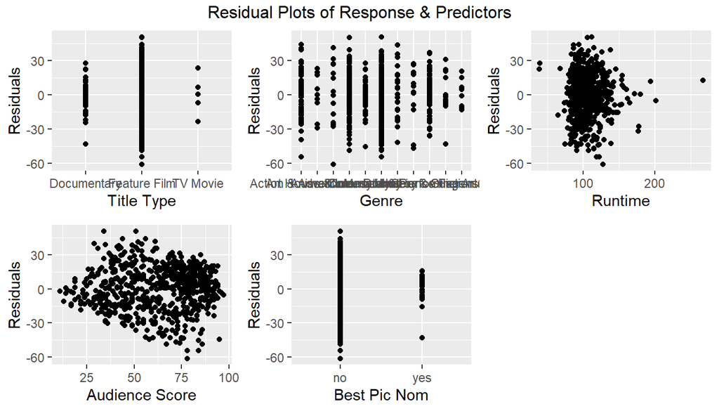

```r
l_rel1 <- ggplot(lm_mov, aes(x = title_type, y = .resid)) +
  geom_point() + xlab("Title Type") + ylab("Residuals")

l_rel2 <- ggplot(lm_mov, aes(x = genre, y = .resid)) +
  geom_point() + xlab("Genre") + ylab("Residuals")

l_rel3 <- ggplot(lm_mov, aes(x = runtime, y = .resid)) +
  geom_point() + xlab("Runtime") + ylab("Residuals")

l_rel4 <- ggplot(lm_mov, aes(x = audience_score, y = .resid)) +
  geom_point() + xlab("Audience Score") + ylab("Residuals")

l_rel5 <- ggplot(lm_mov, aes(x = best_pic_nom, y = .resid)) +
  geom_point() + xlab("Best Pic Nom") + ylab("Residuals")

grid.arrange(l_rel1, l_rel2, l_rel3, l_rel4, l_rel5, ncol = 3, top = "Residual Plots of Response & Predictors")
```

Here we can observe that the residuals are somehow randomly scattered around 0.

### Nearly normal residuals

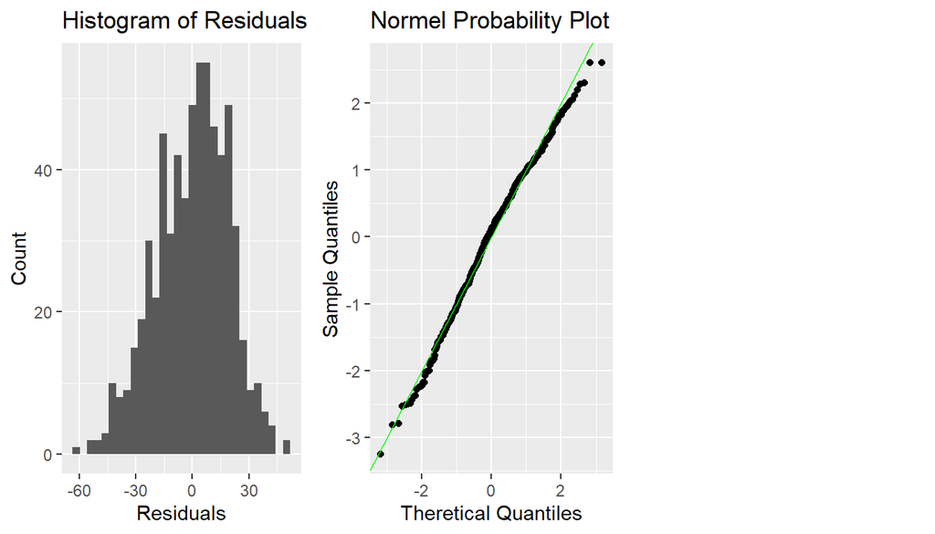

```r
l_rel6 <- ggplot(lm_mov, aes(x = .resid)) + geom_histogram() + xlab("Residuals") + ylab("Count") + ggtitle("Histogram of Residuals")
l_rel7 <- ggplot(lm_mov, aes(sample = .stdresid)) + stat_qq() + xlab("Theretical Quantiles") + ylab("Sample Quantiles") + ggtitle("Normel Probability Plot") + geom_abline(colour = "green")
grid.arrange(l_rel6, l_rel7, ncol = 3)
```

These plots show that the residuals are nearly normally distributed.

### Approximate constant variablilty of residuals

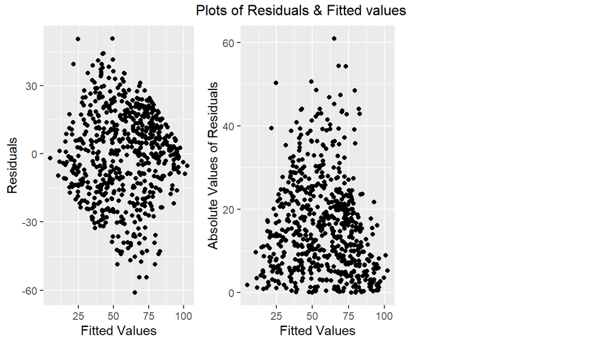

```r
l_rel8 <- ggplot(lm_mov, aes(x = .fitted, y = .resid)) + geom_point() + xlab("Fitted Values") + ylab("Residuals")
l_rel9 <- ggplot(lm_mov, aes(x = .fitted, y = abs(.resid))) + geom_point() + xlab("Fitted Values") + ylab("Absolute Values of Residuals")
grid.arrange(l_rel8, l_rel9, ncol = 3, top = "Plots of Residuals & Fitted values")
```

The plots above show a little aberation from our hypothesis of homoscedasticity. We should keep it in mind when we wrap up our project.

### Independence of residuals

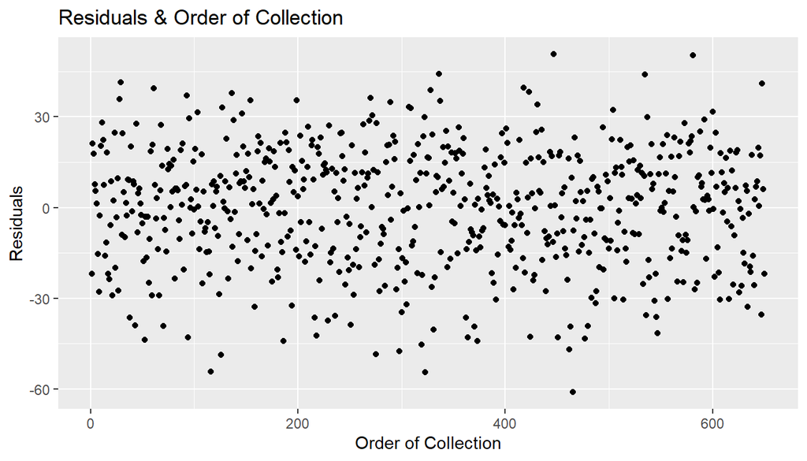

```r
ggplot(fortify(lm_mov), aes(x = seq_along(.resid), y = .resid)) + geom_point() + xlab("Order of Collection") + ylab("Residuals") + ggtitle("Residuals & Order of Collection")
```

Observing the plot above, we can assume that the residusals are independant.

## Interpretation of Model Coefficients.

For curiosity, let’s analyze the coefficients of our model lm_mov

```r
summary(lm_mov)
```

```
##
## Call:
## lm(formula = critics_score ~ title_type + genre + runtime + audience_score +
##     best_pic_nom, data = movies_simp)
##
## Residuals:
##     Min      1Q  Median      3Q     Max
## -61.031 -13.630   2.065  14.264  50.703
##
## Coefficients:
##                                 Estimate Std. Error t value Pr(>|t|)
## (Intercept)                     13.01978    9.10202   1.430 0.153087
## title_typeFeature Film         -23.23139    7.17772  -3.237 0.001273 **
## title_typeTV Movie             -17.02038   11.40626  -1.492 0.136145
## genreAnimation                   2.04125    6.99450   0.292 0.770507
## genreArt House & International   1.40810    5.76928   0.244 0.807257
## genreComedy                      0.30184    3.21969   0.094 0.925338
## genreDocumentary                -1.84898    7.70307  -0.240 0.810383
## genreDrama                       9.90235    2.72476   3.634 0.000301 ***
## genreHorror                      9.99387    4.77086   2.095 0.036587 *
## genreMusical & Performing Arts   4.08627    6.65594   0.614 0.539482
## genreMystery & Suspense         11.06317    3.52096   3.142 0.001756 **
## genreOther                      10.54292    5.52417   1.909 0.056777 .
## genreScience Fiction & Fantasy  11.21856    6.94376   1.616 0.106672
## runtime                          0.04700    0.04364   1.077 0.281925
## audience_score                   0.86946    0.04377  19.866  < 2e-16 ***
## best_pic_nomyes                  7.57877    4.50293   1.683 0.092853 .
## ---
## Signif. codes:  0 '***' 0.001 '**' 0.01 '*' 0.05 '.' 0.1 ' ' 1
##
## Residual standard error: 19.52 on 634 degrees of freedom
## Multiple R-squared:  0.539,  Adjusted R-squared:  0.5281
## F-statistic: 49.41 on 15 and 634 DF,  p-value: < 2.2e-16
```

### Coefficient of title_type:TV Movie

The coefficient of the variable title_type:TV Movie is -17.02038. In this case, the baseline is “Documentary”, therefore if all else held constant, the critics score of “TV Movie” is -17.02038 points lower that “Documentary” movies on average. * * *

## Part 5: Prediction

We will try critics score on movie whih titles “Harry Potter and the Chamber of Secrets”. The data below shows information the movies

```r
harry_cham <- data.frame(title_type = "Feature Film", genre = "Science Fiction & Fantasy", runtime = 161, audience_score = 79, best_pic_nom = "no")
harry_cham
```

```
##     title_type                     genre runtime audience_score best_pic_nom
## 1 Feature Film Science Fiction & Fantasy     161             79           no
```

```r
harry_cham_pred <- predict(lm_mov, newdata = harry_cham, interval = "prediction")
harry_cham_pred
```

```
##        fit      lwr      upr
## 1 77.26161 36.50052 118.0227
```

The prediction for “Harry Potter and the Chamber of Secrets” is 77.26161. Our 95% prediction interval for this prediction is [36.50052, 118.0227]. This means that we are 95% confident that actual score is between this two numbers. Indeed, the critics score for the movie is 82 which is close to 77 and included in our interval.

## Part 6: Conclusion

As a result, we can actually anticipate the popularity of a movie (as we represent it by critics score) by knowing its, title type, genre, audience score, runtime and Best Picture Nomination. Althogh, we could have done this by using less variables, because the increse of adjusted-R-squared from runtime, best picture nomination and others, leaving only audience score. Even including all of them yields only 52.81 %, so this means that approximately 52.81% of variability is explained by the model, which is sufficient, but not even close to perfection. Due to it we can observe differences between our model result and the actual result from “movies.data”

Futhermore, we should also mention that we could not approve our model hypothesis of homoscedasticity; the variablility of the residuals did not exhibit a nearly constant pattern. As the linear model assumptions were not fully respected, we ought to examine our conclusions with considerable caution.